# Colorado

Marcela Suárez

July 25, 2019

This document presents the results obtained for Colorado.

## **Analysis with the whole dataset**

#### **A general overview of the dataset**

```
## Classes 'spec_tbl_df', 'tbl_df', 'tbl' and 'data.frame': 5915 obs. of  7 variables:
##  $ lat      : num  40 40 42.3 40 40 ...
##  $ lon      : num  -105.3 -105.2 -71.7 -105.3 -105.3 ...
##  $ date     : POSIXct, format: "2013-09-27 11:38:37" "2013-09-27 13:32:11" ...
##  $ state    : chr  "Colorado" "Colorado" "Massachusetts" "Colorado" ...
##  $ text     : chr  "Breakfast looks good. Thanks naturespath. #fitsocial  #healthyfood #boulder @ Millennium Harvest House… http://t.co/KyRHM9PQ0B" "#Volunteering in #boulder clearing up flood trash. Glad to help Fernando today clear out his basement.… http://t.co/L6JsOZ88tw" "I need to go to Bou…
##  $ user     : chr  "Alexandra Williams" "Calan Breckon" "Annelyse Reinertson" "Ian Cairns" ...
##  $ u_profile: chr  "Twin & I R fitness experts.Writer/Editor/Speaker/Radio Host.Fun & Fit. ACE Cert. Contrib.Ed. IDEA Fitness Jrnal"| __truncated__ "- #Gay World Traveller on a year long trip around North America -\r Get Inspired | #GetRAOKT | #TTOT | Currently in #Oklahoma" "21. Painting major @…
```

Tweets were collected from 2013-09-01 00:00:48 to 2013-09-30 23:52:05

#### **Temporal stages**

Four stages were defined:

- *Preflood*: From 2013-09-01 00:00:48 to 2013-09-11 00:00:00.
- *Flood*: From 2013-09-11 00:00:00 to 2013-09-16 00:00:00.
- *Immediate Aftermath*: From 2013-09-16 00:00:00 to 2013-09-23 00:00:00.
- *Postflood*: From 2013-09-23 00:00:00 to 2013-09-30 23:52:05.

#### **Cleaning dataset**

- *Removing retweets:*

  From the original dataset containing 5915 tweets, only 5846 were retained.
- *Removing tweets sent by bots:*

  Tweets sent by [TwitZIP](http://twitzip.com/), a bot service to discover local neighborhood news, were removed. After this process 4916 were retained. Other three bot accounts *(“TMJ-COB PM Jobs”, “JobsDirectUSA.com”, “Whole Foods”)* were detected and tweets were removed. A total of 4158 tweets were retained.
- *Removing urls, usernames, punctuation and numbers:*

  All references to usernames, urls and punctuation and numbers were removed from each tweet in order to prepare the dataset for tokenization.

#### **Most common words**

A quick view of the most common words in the whole dataset:

```
## # A tibble: 7,764 x 2
##    word             n
##    <chr>        <int>
##  1 boulder       3242
##  2 boulderflood   544
##  3 colorado       449
##  4 coflood        427
##  5 cowx           402
##  6 flood          269
##  7 flooding       203
##  8 amp            197
##  9 rain           186
## 10 creek          173
## # … with 7,754 more rows
```

Since **“boulder”** is the most common word and is going ot have a big effect in our topic modelling, it was removed from the dataset. The following five terms *(“boulderflood”, “colorado”, “coflood”, “cowx”, “flood”)* were also excluded because they were so common and used neutrally in all four stages. After excluding these six terms, the new list of common words looks as follows:

```
## # A tibble: 7,758 x 2
##    word         n
##    <chr>    <int>
##  1 flooding   203
##  2 amp        197
##  3 rain       186
##  4 creek      173
##  5 denver     147
##  6 county     130
##  7 day        128
##  8 rt         116
##  9 city       110
## 10 people     106
## # … with 7,748 more rows
```

The statistic **tf-idf** was computed in order to identify which words are important in each of the flood stages. It measures how important a word is to a document in a collection (or corpus) of documents, in our case, it measures how important a word is to a tweet in a collection of tweets. In this case the collection of tweets was the set of tweets belonging to each stage.

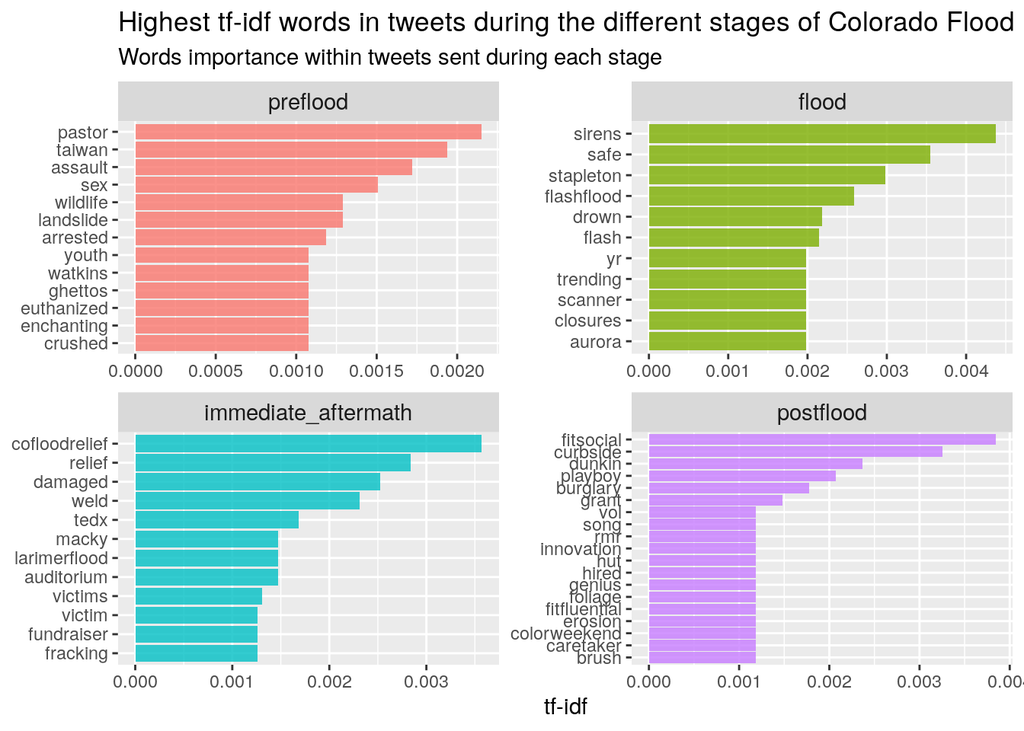

#### **Topic Modeling**

After playing with different numbers, I decided to train a topic model with 4 topics. From 5 on, topics started to look very similar (with the same bag of words). Here is a summary of the results after this process:

```
## Beginning Spectral Initialization
##   Calculating the gram matrix...
##   Finding anchor words...
##      ....
##   Recovering initialization...
##      .............................................................................
## Initialization complete.
## ....
## Completed E-Step (0 seconds).
## Completed M-Step.
## Completing Iteration 1 (approx. per word bound = -7.448)
## ....
## Completed E-Step (0 seconds).
## Completed M-Step.
## Completing Iteration 2 (approx. per word bound = -7.406, relative change = 5.618e-03)
## ....
## Completed E-Step (0 seconds).
## Completed M-Step.
## Model Converged
```

```
## A topic model with 4 topics, 4 documents and a 7758 word dictionary.
```

```
## Topic 1 Top Words:
##       Highest Prob: flooding, rain, safe, creek, rt, stay, water
##       FREX: sirens, stapleton, flashflood, drown, aurora, closures, scanner
##       Lift: ++, ~min, ☁⚡☔, ☔, ☺, ⚡, ⛅
##       Score: safe, ++, sirens, flash, stapleton, flashflood, trending
## Topic 2 Top Words:
##       Highest Prob: amp, denver, day, city, beautiful, county, snow
##       FREX: fitsocial, curbside, dunkin, playboy, burglary, snow, grant
##       Lift: ❤gopios, advisory, bookstore, bra, contractor, delta, doortodoor
##       Score: ❤gopios, fitsocial, curbside, dunkin, playboy, burglary, grant
## Topic 3 Top Words:
##       Highest Prob: amp, denver, creek, day, park, cu, bear
##       FREX: pastor, taiwan, assault, sex, landslide, wildlife, crushed
##       Lift: °, accident, af, agree, atlas, bird, breast
##       Score: °, pastor, taiwan, assault, sex, arrested, youth
## Topic 4 Top Words:
##       Highest Prob: amp, county, city, people, rain, creek, victims
##       FREX: cofloodrelief, damaged, weld, tedx, auditorium, larimerflood, macky
##       Lift: →★ironic★, gallons, recover, timberline, tracking, add, ampm
##       Score: →★ironic★, relief, cofloodrelief, damaged, weld, victims, tedx
```

The probabilities that each word is generated from each topic are shown below:

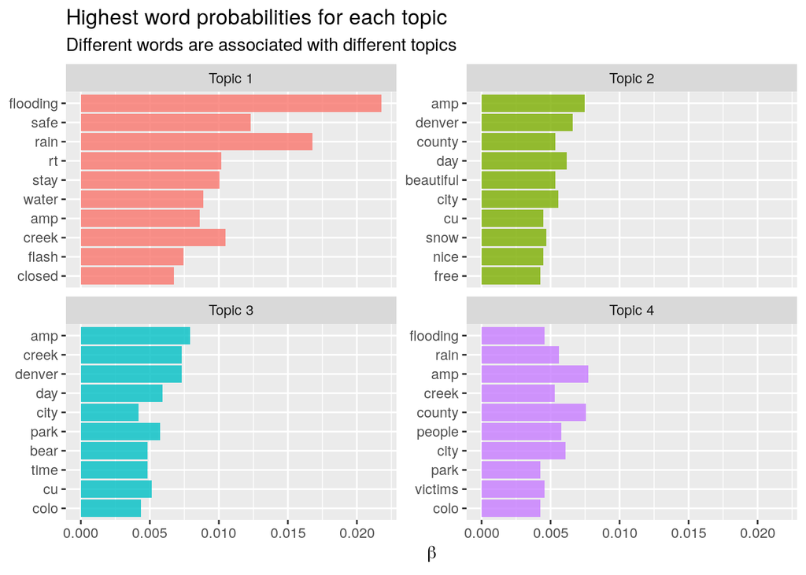

From this, we can’t demonstrate yet a clear association of these topics with the four stages of the disaster.

On the other hand, besides estimating each topic as a mixture of words, LDA also models each document (tweet in our case) as a mixture of topics. We can examine the per-document-per-topic probabilities, called the “gamma probability”. So, looking at the probability that each document (tweet) is generated from each topic:

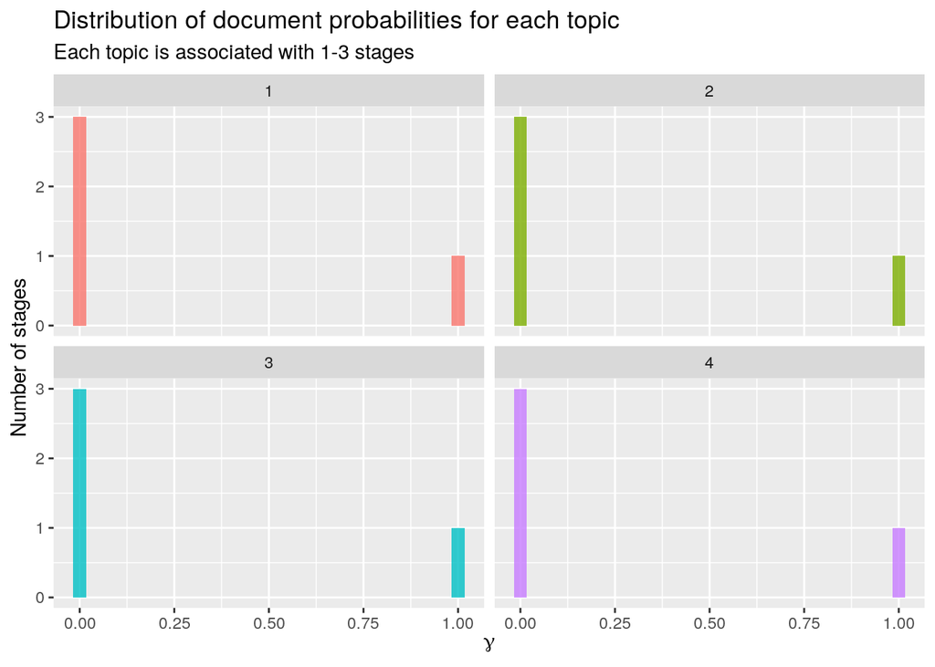

From the plot above, we can see that each stage is strongly associated with a single topic. Gamma probabilities tell us which topics are coming from which documents (tweets).

## **Analysis with a subset of the data**

Now I will repeat the same analysis but considering tweets sent from what should be the “affected area”.

#### **Spatial Clustering**

In order to identify tweets sent from the afected area, a hierarchical spatial clustering was applied to the data.

Before doing so, the data was first projected in North America Lambert Conformal Conic.

Then, a hierarchical implementation of dbscan was used **(hdscan)**, considering a minimum of 350 tweets per cluster.

[interactive chart not shown]

#### **Most common words (Within Spatial Clusters)**

```
## # A tibble: 5,251 x 2
##    word             n
##    <chr>        <int>
##  1 boulder       1998
##  2 boulderflood   373
##  3 colorado       262
##  4 cowx           201
##  5 flood          173
##  6 coflood        129
##  7 amp            126
##  8 flooding       123
##  9 creek          111
## 10 rain           110
## # … with 5,241 more rows
```

```
## # A tibble: 5,246 x 2
##    word         n
##    <chr>    <int>
##  1 coflood    129
##  2 amp        126
##  3 flooding   123
##  4 creek      111
##  5 rain       110
##  6 denver      94
##  7 county      89
##  8 colo        88
##  9 day         76
## 10 cu          72
## # … with 5,236 more rows
```

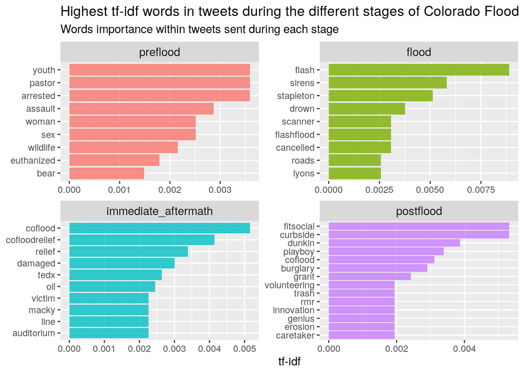

#### **Topic Modeling**

Again, after playing with different numbers, I decided to train a topic model with 5 topics. From 6 on, topics started to look very similar (with the same bag of words). Here is a summary of the results after this process:

```
## Beginning Spectral Initialization
##   Calculating the gram matrix...
##   Finding anchor words...
##      .....
##   Recovering initialization...
##      ....................................................
## Initialization complete.
## ....
## Completed E-Step (0 seconds).
## Completed M-Step.
## Completing Iteration 1 (approx. per word bound = -7.104)
## ....
## Completed E-Step (0 seconds).
## Completed M-Step.
## Completing Iteration 2 (approx. per word bound = -7.077, relative change = 3.861e-03)
## ....
## Completed E-Step (0 seconds).
## Completed M-Step.
## Completing Iteration 3 (approx. per word bound = -7.077, relative change = 1.091e-05)
## ....
## Completed E-Step (0 seconds).
## Completed M-Step.
## Model Converged
```

```
## A topic model with 5 topics, 4 documents and a 5246 word dictionary.
```

```
## Topic 1 Top Words:
##       Highest Prob: flooding, rain, creek, rt, water, amp, coflood
##       FREX: flash, sirens, stapleton, drown, cancelled, flashflood, scanner
##       Lift: ~min, ☁⚡☔, ⚡, ⛅, ❤✌, aaaaah, abandoned
##       Score: flash, ~min, sirens, stapleton, drown, roads, lyons
## Topic 2 Top Words:
##       Highest Prob: coflood, amp, denver, county, colo, cu, beautiful
##       FREX: curbside, fitsocial, travel, dunkin, snow, playboy, donuts
##       Lift: ❤️, $coflood, $hr, $m, aa, abos, abroad
##       Score: ❤️, curbside, fitsocial, coflood, dunkin, playboy, burglary
## Topic 3 Top Words:
##       Highest Prob: amp, denver, colo, day, cu, creek, park
##       FREX: arrested, pastor, youth, assault, sex, woman, wildlife
##       Lift: °, accident, agree, bird, breast, brett, bubble
##       Score: °, arrested, pastor, youth, bear, assault, police
## Topic 4 Top Words:
##       Highest Prob: coflood, county, amp, colo, creek, market, flooding
##       FREX: cofloodrelief, damaged, tedx, auditorium, line, macky, victim
##       Lift: ▪frєє, ☀️, ❄️, $$, accepted, advocacy, aftermath
##       Score: ▪frєє, coflood, cofloodrelief, relief, damaged, tedx, oil
## Topic 5 Top Words:
##       Highest Prob: coflood, amp, denver, county, colo, cu, ❤gopios
##       FREX: curbside, fitsocial, travel, snow, dunkin, $, free
##       Lift: ❤gopios, brush, concern, contractor, delta, doortodoor, hired
##       Score: ❤gopios, curbside, fitsocial, coflood, dunkin, playboy, burglary
```

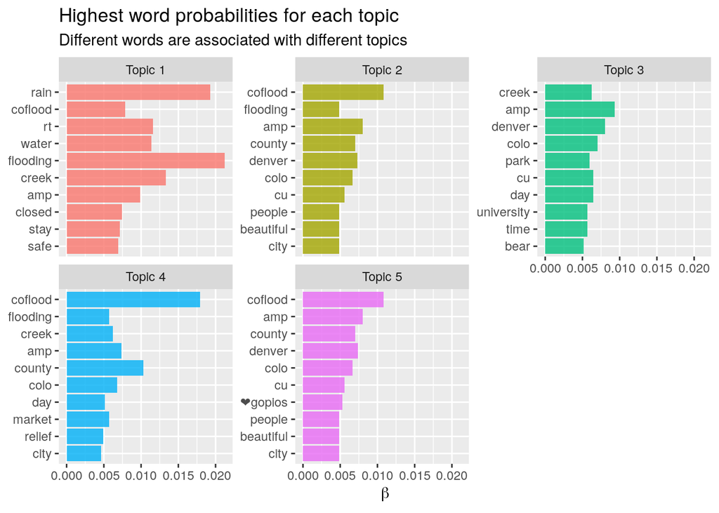

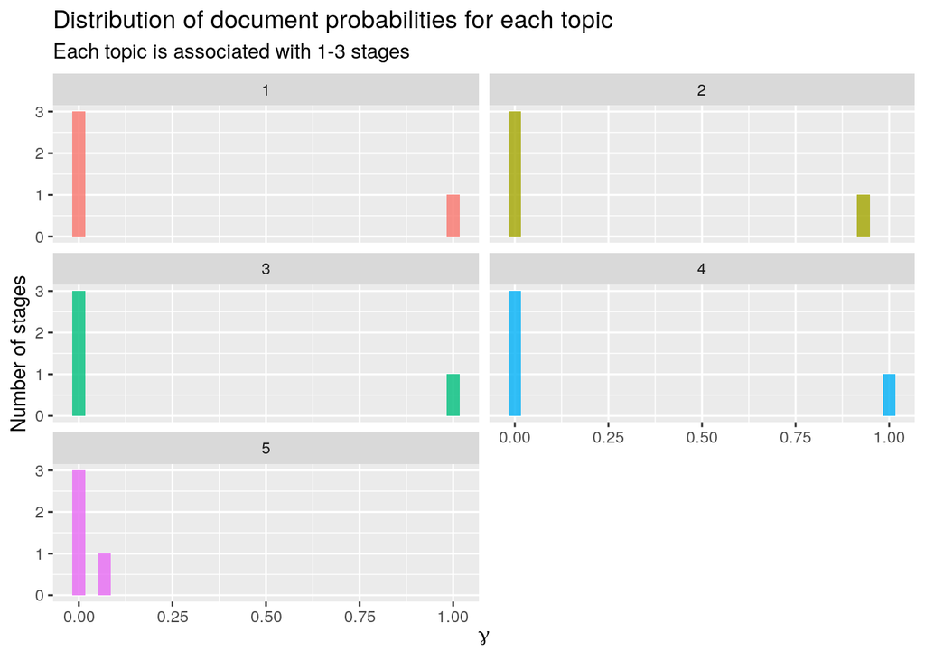